# Project

```python
student_name = 'Yutae Lee'
```

# Introduction

In this project you will be introduced to some basic algorithmic concepts related to sorting, and then be asked to implement and test two variations of the quicksort algorithm.

## Quicksort

The quicksort algorithm is a divide and conquer algorithm originally developed in 1959 by Tony Hoare while in the Soviet Union, as a visiting student at Moscow State University. This method effectively partitions the input data with respect to a pivot, and then recursively applies the algorithm to each subproblem defined by the pivot.

[Wikipedia](https://en.wikipedia.org/wiki/Quicksort) has an article describing the history and several variants of the algorithm.

## Algorithm Overview

- Divide: Choose a pivot, an element from the list, and partition the list so the at all elements less than the pivot are in one partition and those greater appear in another partition.
- Conquer: Recursively apply this to each sublist (partition)
- Combine: Combine the results. Typically this is trivial as the above steps are performed in place.

## Complexity

We commonly use asymptotic notation to describe the running time or space requirements of algorithms. This notation is intended to describe the order of growth of an algorithm's running time (or space requriements), which in turn allows us to better understand the efficiency and relative performance of algorithms.

There are several types of asymptotic notation, the three most common are defined below (Big-Oh, $O(\cdot)$, is the most widely used):

$\Theta(g(n)) = \{f(n) : \exists\; c_1, c_2, n_0 > 0 \mid 0 \le c_1 g(n) \le f(n) \le c_2 g(n) \;\forall n \ge n_0 \}$

$O(g(n)) = \{f(n) : \exists\; c, n_0 > 0 \mid 0 \le f(n) \le c g(n) \;\forall n \ge n_0 \}$

$\Omega(g(n)) = \{f(n) : \exists\; c, n_0 > 0 \mid 0 \le c g(n) \le f(n) \;\forall n \ge n_0 \}$

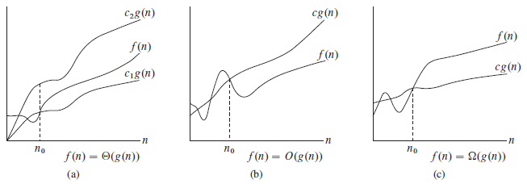

**Source**: *Introduction to Algorithms (3rd edition)* by Thomas H. Cormen, Charles E. Leiserson, Ronald L. Rivest, Clifford Stein, page 45, figure 3.1.

### Quicksort Time Complexity

There are many schemes for the selection of a pivot and partition. The choice of which can greatly affect the overall algorithms performance. Below are the theoretical time complexities for the general algorithm.

- Worst Case $O(n^2)$
- Best Case $\Omega(n\;log\;n)$
- Average Case $\Theta(n\;log\;n)$

### Quicksort Space Complexity

The in-place unstable version uses $O(log\;n)$ space, however, as with algorithm performance, the space used by the algorithm depends on the version used.

### Comparison

| Algorithm | Best Case | Average Case | Worst Case | Worst Case (Space) |
| --- | --- | --- | --- | --- |
| Bubble | $\Omega(n)$ | $\Theta(n^2)$ | $O(n^2)$ | $O(1)$ |
| Bucket | $\Omega(n+k)$ | $\Theta(n+k)$ | $O(n^2)$ | $O(n)$ |
| Counting | $\Omega(n+k)$ | $\Theta(n+k)$ | $O(n+k)$ | $O(k)$ |
| Heap | $\Omega(n\;log\;n)$ | $\Theta(n\;log\;n)$ | $O(n\;log\;n)$ | $O(1)$ |
| Insertion | $\Omega(n)$ | $\Theta(n^2)$ | $O(n^2)$ | $O(1)$ |
| Merge | $\Omega(n\;log\;n)$ | $\Theta(n\;log\;n)$ | $O(n\;log\;n)$ | $O(n)$ |
| Quick | $\Omega(n\;log\;n)$ | $\Theta(n\;log\;n)$ | $O(n^2)$ | $O(log\;n)$ |
| Radix | $\Omega(nk)$ | $\Theta(nk)$ | $O(nk)$ | $O(n+k)$ |
| Selection | $\Omega(n^2)$ | $\Theta(n^2)$ | $O(n^2)$ | $O(1)$ |
| Shell | $\Omega(n\;log\;n)$ | $\Theta(n(log\;n)^2)$ | $O(n(log\;n)^2)$ | $O(1)$ |
| Tree | $\Omega(n\;log\;n)$ | $\Theta(n\;log\;n)$ | $O(n^2)$ | $O(n)$ |

## Stability

A sorting algorithm is said to be stable if equal items appear in the same order in both the input and the sorted output of the algorithm. This may not be interesting for integers (for example), but it can be important for objects that are sorted by keys.

The basic version of quicksort is unstable, but stable variants do exist.

For more information on the stability in sorting algorithms, check out [Stability in sorting algorithms](https://www.geeksforgeeks.org/stability-in-sorting-algorithms/).

# Instructions

In this project you will implement two versions of Quicksort and compare their running times on various input data.

1. Write a recursive function, `quicksort_lomuto`, that sorts an input list using the Lomuto partitioning scheme described below.
2. Write a recursive function, `quicksort_hoare`, that sorts an input list using the Hoare partitioning scheme described below.
3. Run the provided test code to compare your implementations. Is there a difference between the runtimes of these two schemes? If so, why?

## Lomuto Partition Scheme

- Choose the last element in the input (sub)list as the pivot
- Set a swap index to the first index of the (sub)list
- For each element in the (sub)list
  - If the element is less than or equal to the pivot
    - Swap the element with the element currently in the swap location
    - Increment the swap location
- Swap the pivot with the element in current swap location
- Return the index of the pivot

After running the above scheme once all elements in the (sub)list that are less than or equal to the pivot appear before the pivot, and all larger elements appear after the pivot. Notice that the pivot is now in its final location in the original input list. Also, by returning the index of the pivot (after it is put in its final location) we can operate on the sublists to the left and right of the pivot.

## Hoare Partition Scheme

This scheme works by starting at each end of the (sub)list and working towards the center until an 'inversion' is found. An inversion occurs when a smaller value than the pivot is found at the right index and a larger value than the pivot is found at the left index. These values are swapped and the search continues.

- Choose the first element in the (sub)list as the pivot
- Set a left index to one before the first index in the (sub)list
- Set a right index to one after the last index in the (sub)list
- Infinite loop
  - Infinite loop
    - Subtract one from the right index
    - Break when the element at the right index is less than or equal to the pivot
  - Infinite loop
    - Add one to the left index
    - Break when the element at the left index is greater than or equal to the pivot
  - If the left index is greater than or equal to the right index
    - Return the right index
  - Swap the elements at the left and right indices

Unlike the Lomuto scheme the pivot is not always placed in its final position after a single pass through the above scheme. Instead the scheme guarantees that for a (sub)list with start index `a` and end index `b` the values in the (sub)list `[a,right]` will be less than the pivot, and those values in `[right+1, b]` will be greater than or equal to the pivot, where `right` is the index returned by the scheme. Thus your implementation of quicksort should **not** assume that the returned index from the above scheme contains a value in its final location.

## Submitting Your Assignment

You will submit your completed assignment in two formats:

- Jupyter Notebook (.ipynb)
- HTML (.html)

##### Jupyter Notebook (.ipynb)

You may directly use this notebook to complete your assignment or you may use an external editor/IDE of your choice. However, to submit your code please ensure that your code works in this notebook.

##### HTML (.html)

To create an HTML file for your assignment simply select `File > Download as > HTML (.html)` from within the Jupyter Notebook.

Both files should be uploaded to [Canvas](https://canvas.tamu.edu).

## Your Solution (1)

Complete the `quicksort_lomuto()` function below.

```python
def quicksort_lomuto(elements, low_idx=None, high_idx=None):
    if low_idx == None:
        low_idx = 0
    if high_idx == None:
        high_idx = len(elements)-1
    """
    This function sorts the elements list in place using the
    Lomuto partitioning scheme.  Only the values in the range
    [low_idx, high_idx] are sorted by a call to this function.

    elements - A list of values to be sorted
    low_idx  - The starting index of the elements list to be
               sorted.  Values appearing before this index are
               not touched. Default is 0.
    high_idx - The ending value of the elements list to be
               sorted.  Values appearing after this index are
               not touched.  Default is len(elements)-1.
    """
    def lomuto_partition_scheme(elements, low_idx, high_idx):# An internal function to partition
        pivot = elements[high_idx] #Set pivot to right most value
        i = low_idx - 1 #Set Swap Location
        for j in range (low_idx,high_idx):
            if elements[j] < pivot: #If the element is less than or equal to the pivot
                i = i+1 #Increment Swap Location
                elements[i], elements[j] = elements[j], elements[i] #Swap the element
        elements[i+1], elements[high_idx] = elements[high_idx], elements[i+1] #Swap the pivot with the element in current swap location
        return (i+1) #Returning index of the pivot
    def quicksort(elements, low_idx, high_idx): #Main Sorting function
        if (low_idx < high_idx): #Check to prevent errors
            partition = lomuto_partition_scheme(elements, low_idx, high_idx)#partition pivot index
            quicksort(elements, low_idx, partition-1)#sorting elements before partition pivot index
            quicksort(elements, partition+1, high_idx)#sorting elements after partition pivot index
    quicksort(elements, low_idx, high_idx) #Actually perform quicksort_lomuto
```

## Your Solution (2)

Complete the `quicksort_hoare()` function below.

```python
def quicksort_hoare(elements,  low_idx=None, high_idx=None):
    if low_idx == None:
        low_idx = 0
    if high_idx == None:
        high_idx = len(elements)-1
    """
    This function sorts the elements list in place using the
    Lomuto partitioning scheme.  Only the values in the range
    [low_idx, high_idx] are sorted by a call to this function.

    elements - A list of values to be sorted
    low_idx  - The starting index of the elements list to be
               sorted.  Values appearing before this index are
               not touched. Default is 0.
    high_idx - The ending value of the elements list to be
               sorted.  Values appearing after this index are
               not touched.  Default is len(elements)-1.
    """
    def hoare_partition_scheme(elements, low_idx, high_idx):# An internal function to partition
        pivot = elements[low_idx] #Set pivot to first element
        i = low_idx - 1 #Set a left index to one before the first index in the (sub)list
        j = high_idx + 1 #Set a right index to one after the last index in the (sub)list

        while (True):
            j = j - 1 #Subtract one from the right index
            while(elements[j]>pivot):#Break when the element at the right index is less than or equal to the pivot
                j = j - 1 #Subtract one from the right index
            i = i + 1 #Add one to the left index
            while(elements[i]<pivot): #Break when the element at the left index is greater than or equal to the pivot
                i = i + 1 #Add one to the left index
            if (i >= j):
                return j
            elements[i],elements[j] = elements[j], elements[i] #Swap the two indexes
    def quicksort(elements, low_idx, high_idx): #Main Sorting
        if (low_idx < high_idx): #Check to prevent errors
            partition = hoare_partition_scheme(elements, low_idx, high_idx)#partitioning index
            quicksort(elements, low_idx, partition)#sorting elements up to partioning index
            quicksort(elements, partition+1, high_idx)
    quicksort(elements, low_idx, high_idx) #Actually perform quicksort_hoare
```

## Test Code (Sanity Check)

After completing the `quicksort_lomuto` and `quicksort_hoare` functions run the following code block to check if your functions produce a sorted list for a randomly generated list of `n` elements. Even if your functions pass this test, bugs still may exist. You should write your own test functions and verify your implementations.

```python
import random


def is_sorted(elements):
    """
    Returns true if elements are in sorted order
    """
    return all(elements[i] <= elements[i + 1] for i in range(len(elements)-1))


def test_random_sample_sort(sort_func, n=10000):
    """
    Creates a list of `n` random samples, sorts it using the passed
    sort function and then verifies that the list is indeed sorted.
    Outputs results to the console.
    """
    elements = random.sample(range(10000), n)
    sort_func(elements)
    if is_sorted(elements):
        print(sort_func.__name__, 'passed sort test')
    else:
        print(sort_func.__name__, 'failed sort test')



# Run quick test using Lomuto scheme
test_random_sample_sort(quicksort_lomuto)
# Run quick test using Hoare scheme
test_random_sample_sort(quicksort_hoare)

elements = random.sample(range(100000),100000)
quicksort_lomuto(elements)
print(is_sorted(elements))

elements = random.sample(range(100000),100000)
quicksort_hoare(elements)
print(is_sorted(elements))
```

```
quicksort_lomuto passed sort test
quicksort_hoare passed sort test
True
True
```

## Test Code (Time Comparison)

After completing the `quicksort_lomuto` and `quicksort_hoare` functions run the following code blocks to compare the runtime performance of your implementations with various inputs. The results of this code block will help you to answer question 3. Note that these code block simply time your code, does not test or verify that the output of your functions is correct.

**Notice**: Increasing the value of the variable `num_repeats` will reduce the noise in the resulting graphs at the expense of additional computation and time. Also, increasing `max_size` will increase testing time, but will give a better view of the asymptotic behavior. Use the stop button in the toolbar if this block is taking too long on your system and reduce these values.

```python
import random, timeit, copy
import matplotlib.pyplot as plt
import time, sys
from IPython.display import clear_output


def update_progress(progress):
    """
    Helper function to display the progress of the tests.
    Source: https://www.mikulskibartosz.name/how-to-display-a-progress-bar-in-jupyter-notebook/
    """
    bar_length = 20
    if isinstance(progress, int):
        progress = float(progress)
    if not isinstance(progress, float):
        progress = 0
    if progress < 0:
        progress = 0
    if progress >= 1:
        progress = 1

    block = int(round(bar_length * progress))
    clear_output(wait = True)
    text = "Progress: [{0}] {1:.1f}%".format( "#" * block + "-" * (bar_length - block), progress * 100)
    print(text)


def plot_time_comparison(sample_func, num_repeats=None,
                         max_size=None, step_size=None,
                         lomuto=quicksort_lomuto,
                         hoare=quicksort_hoare):
    """
    Records and plots the runtimes of the quicksort_lomuto and
    quicksort_hoare functions using input lists generated with
    sample_func.

    sample_func: Expected to take a single argument n and return
                 a length n list of values.
    num_repeats: The number of timing tests that will be average
                 together for a single input list.
    max_size:    The maximum size list that will be considered
                 by this function.  Sizes will be tested in the
                 range [1, max_size]
    step_size:   The increment value to be used while testing.
                 If step_size=1 then all list lengths in the
                 range [1, max_size] will be tested.  Instead
                 if step_size=10, then the lengths 1, 11, 21,
                 ... will be tested until max_size is reached
                 or exceeded.
    """
    # The number of times the quicksort function will be called on a
    # given input list.  The timing results will be averaged over these
    # repeated executions.
    if num_repeats is None:
        num_repeats = 10

    # The maximum size list to consider
    if max_size is None:
        max_size = 1000

    # The step to be used - compute time for every `step_size` values
    if step_size is None:
        step_size = 10

    # Storage for the time data for each test below
    time_lomuto = []
    time_hoare = []

    # Time the sorting of random lists with sizes ranging from 1
    # to max_size
    for n in range(1, max_size, step_size):

        # Create our random list of length n
        elements = sample_func(n)

        # Lomuto Timing Test
        timer = timeit.Timer(lambda: lomuto(copy.deepcopy(elements), 0, n-1))
        t = timer.timeit(number = num_repeats)
        time_lomuto.append(t / num_repeats)

        # Hoare Timing Test
        timer = timeit.Timer(lambda: hoare(copy.deepcopy(elements), 0, n-1))
        t = timer.timeit(number = num_repeats)
        time_hoare.append(t / num_repeats)

        # Update the progress bar
        update_progress((n-1) / max_size)
    update_progress(1)

    plt.plot(range(1, max_size, step_size), time_lomuto, 'b')
    plt.plot(range(1, max_size, step_size), time_hoare, 'r')
    plt.legend(['Lomuto', 'Hoare'])
    plt.tick_params(axis='y', which='both', labelleft='on', labelright='on')
    plt.show()
```

### Randomly Generated Lists

The following tests your functions using randomly generated lists of increasing lengths.

```
Progress: [####################] 100.0%
```

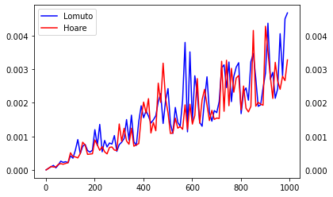

```python
plot_time_comparison(lambda n : random.sample(range(100000), n))
```

### Pre-Sorted Inputs

The following tests your functions using lists of increasing lengths whose elements are already sorted from small to large.

```
Progress: [####################] 100.0%
```

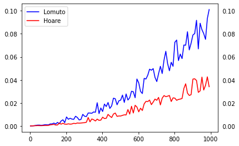

```python
plot_time_comparison(lambda n : list(range(n)))
```

### Constant Inputs

The following tests your functions using lists of increasing lengths whose elements are all equal.

```
Progress: [####################] 100.0%
```

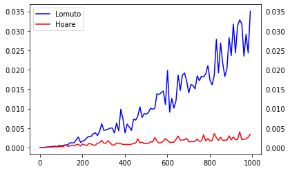

```python
plot_time_comparison(lambda n : [n]*n)
```

## Your Solution (3)

Is there a difference between the runtimes of these two schemes? If so, why?

When sorting n randomly generated list the two functions do not show clear difference, however there is a clear difference when we are considering lists that are either already sorted in that Hoare takes significantly less amount of time. The reason behind is in Hoare algorithm, the number of time wasted in swapping is reduced as we are swapping two at a time while in Lomuto, the swapping process is done one at a time. Thus, Hoare must be more efficient way of quick sorting.